# PHOT 110: Introduction to programming

PHOT 110: Introduction to programming

LECTURE 07: Modules (Ch. 4.9)

Michaël Barbier

Version: April 19, 2026

# Modules (Ch. 4.9)

## Using modules

- Import modules with the **`import`** keyword
- Dot-notation to select sub-modules, objects, functions

Example: `math` is a **module**

```python
import math
print(type(math))
```

```
<class 'module'>
```

## Dot-notation: select sub-modules, objects, functions

- The `math` module contains **functions** and other **objects**

Contains a variable with a value for $\pi$

```python
math.pi
```

```
3.141592653589793
```

```python
type(math.pi)
```

```
float
```

Contains function $\sin()$

```python
type(math.sin)
```

```
builtin_function_or_method
```

## Dot-notation: select sub-modules, objects, functions

- `numpy` is a module

```python
import numpy
print(type(numpy))
```

```
<class 'module'>
```

- also contains functions, sub-modules, attributes

```python
print(type(numpy.random))
print(type(numpy.random.normal))
print(type(numpy.pi))
```

```
<class 'module'>
<class 'method'>
<class 'float'>
```

## Beware: dot-notation for methods

- A method is a function bound to an object
- Called on an object: `object.method()`

An example object is a list:

```python
# list objects: reverse(), sort(), ...
my_list = ["apple", 1, True, "five"]
print(my_list)
```

```
['apple', 1, True, 'five']
```

Applying the method `reverse()` to change the object:

```python
my_list.reverse()
print(my_list)
```

```
['five', True, 1, 'apple']
```

## Beware: dot-notation for methods

- A method is a function bound to an object
- Called on an object: `object.method()`

Another example object is a string:

```python
# str objects: upper(), substring() ...
my_string = "apple cake"
print(my_string)
```

```
apple cake
```

Applying the method `upper()` to obtain the string in all-caps:

```python
all_caps_string = my_string.upper()
print(all_caps_string)
```

```
APPLE CAKE
```

## Beware: dot-notation for methods

- A method is a function bound to an object
- Called on an object: `object.method()`

Another example object is a string:

```python
# str objects: upper(), substring() ...
my_string = "apple cake"
print(my_string)
```

```
apple cake
```

The method `replace()` can have arguments:

```python
changed_string = my_string.replace("apple", "banana")
print(changed_string)
```

```
banana cake
```

# Creating modules

## What is a module ?

- A **separate** Python script
- Contains variables, **functions**, classes, etc.
- Can be **imported**

Example:

```
module_print.py
```

```python
def print_dollar(text):
  """
  Print text surrounded
  by dollar symbols
  """
  print("$" + text + "$")
```

```
script.py
```

```python
# Import the module
import module_print as mp

# Use a function
mp.print_dollar("x + 4")
```

```
$x + 4$
```

## Another example of a module

```
tranformations.py
```

```python
import numpy as np

def rotate(xys, angle):
  """ Rotates points around the origin """
  rot_matrix = np.array(
    [[np.cos(angle), -np.sin(angle)],
    [np.sin(angle), np.cos(angle)]])
  return np.dot(rot_matrix, xys)

def translate(xys, displacement):
  """ Translates points with a displacement vector """
  return xys + displacement

def scale(xys, scale):
  """ Scale the point coordinates """
  return xys * scale
```

## Using the module

```
script.py
```

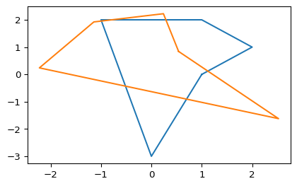

```python
# import our module
import transformations as transfo

shape = np.array([[1, 2, 1, -1, 0, 1], [0, 1, 2, 2, -3, 0]])
rot_shape = transfo.rotate(shape, 1)
plt.plot(shape[0,:], shape[1,:])
plt.plot(rot_rot[0,:], rot_shape[1,:])
plt.show()
```

## Why use modules ?

- **Re-use** function definitions over multiple scripts
- **Readability**: One very long script is not readable:
  - Break up code in **independent parts**
  - Further **structure your code**
- Structure example, divide into:
  - file input/output
  - calculations
  - plotting
  - AND your main script as a separate file

## Testing the functions in your module

- When importing a module, its code is executed
- Function definitions don’t have side-effects

But … any code that **prints**, **changes a variable**, **plots**, or outputs something would be executed on **import** !

Solution: using the `__name__` variable

## Using the `__name__` variable

- `__name__` is always defined
- `__name__` contains:
  - name of the module (file name) if imported
  - `"__main__"` if run as a script

```
my_module.py
```

```python
... module functions ...

if __name__ == "__main__":
  <statements>
```

## Using the `__name__` variable

- `__name__` is always defined
- `__name__` contains:
  - name of the module (file name) if imported
  - `"__main__"` if run as a script

```
my_module.py
```

```python
def increment(x):
  return x + 1

if __name__ == "__main__":
  # Run the test functions
  print(f"The value of 3 + 1 = {increment(3)}")
```

```
The value of 3 + 1 = 4
```

## Importing without `__name__ == "__main__"`

```
tranformations.py
```

```python
import numpy as np
import matplotlib.pyplot as plt

def scale(xys, scale):
  """ scales points by scale """
  return xys * scale

# Testing the scale function
shape = np.array([[1, 2, 1, -1, 0, 1], [0, 1, 2, 2, -3, 0]])
scaled_shape = scale(shape, 3)
plt.plot(shape[0,:], shape[1,:])
plt.plot(scaled_shape[0,:], scaled_shape[1,:])
plt.show()
```

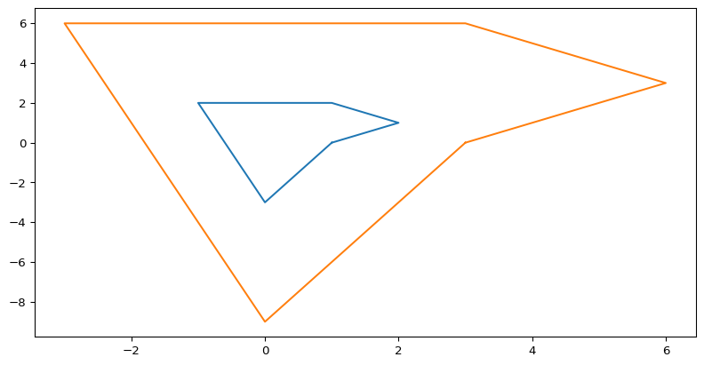

## Importing without `__name__ == "__main__"`

```
main_script
```

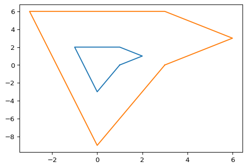

```
Not doing anything except printing this !
```

```python
import transformations
print("Not doing anything except printing this !")
```

## Avoiding side effects

```
tranformations.py
```

```python
import numpy as np
import matplotlib.pyplot as plt

def scale(xys, scale):
  """ scales points by scale """
  return xys * scale

# Only execute tests if run as script
if __name__ == "__main__":
  shape = np.array([[1, 2, 1, -1, 0, 1], [0, 1, 2, 2, -3, 0]])
  scaled_shape = scale(shape, 3)
  plt.plot(shape[0,:], shape[1,:])
  plt.plot(scaled_shape[0,:], scaled_shape[1,:])
  plt.show()
```

## Documenting modules

```
transformations.py
```

```python
""" Geometrical transformations on points in 2D.

Provides functionality for rotation, translation,
or scaling of (x, y)-coordinates. Coordinates
should be given as (2 x N) Numpy arrays where N
is the number of points.

Typical usage example:
  points = np.array([[1, 4, 6],[2, 5, 3]])
  scaled_points = scale(points, 3)
"""
import numpy as np

# ... code of the module ...
```

# Creating an executable of your script

## How to create an executable ?

- Run a script as an **executable**
  - without Python interpreter
  - Directly runnable (by “double clicking”)
- Two good options (as of 2024)
  - **Pyinstaller**
  - **Nuitka** (up to Python version 3.11)
- These compilers **incorporate the Python interpreter** within the executable $\rightarrow$ the resulting **executables are large**.

## Using pyinstaller

**Pyinstaller** works for (our) **Python version 3.12**.

Follow the instructions below to create an executable:

1. Make a new project for your script
2. Copy your script in the new project (or write it)
3. Install the dependencies (required packages)
4. Install the pyinstaller package
5. Execute below line (change the script file name to your own file name) in the **terminal**:

```bash
pyinstaller --onefile your_script.py
```

# Python packages vs. modules

## What is a Python package ?

- **Collection of modules**
- You can **import** the top-module
- Prepared for **distribution**
  - **Sharing** your application
  - Installing
- Can be shared on the [Python Package Index: PyPI](https://pypi.org/)

## Creating a Python package ?

- **setup.py** as advised in the book is the old way, new way:
- Write a pyproject.toml file to [package a Python project](https://packaging.python.org/en/latest/guides/writing-pyproject-toml/)
- Easiest way: use Package and Dependency Managers:
  - [Poetry](https://python-poetry.org/): works in PyCharm out-of-the-box, see the [PyCharm JetBrains page](https://www.jetbrains.com/help/pycharm/poetry.html)
  - [Rye](https://rye.readthedocs.io/en/latest/index.html): has a plugin for PyCharm
  - [PDM](https://pdm-project.org/latest/): works not well together with PyCharm yet

## Example .toml file

```
pyproject.toml
```

```
[build-system]
requires = ["setuptools", "setuptools-scm"]
build-backend = "setuptools.build_meta"

[project]
name = "my_package"
authors = [{name = "Michael Barbier"},]
description = "My package description"
readme = "README.md"
license = {text = "BSD-3-Clause"}
dependencies = ["numpy",]

[project.scripts]
my-script = "my_package.module:function"
```